# Propensity Score Matching from Scratch

Causal Inference Course

2026-01-28

# Introduction

This tutorial implements propensity score matching manually to understand exactly what happens at each step. We’ll use explicit for loops instead of package functions to make the process transparent.

## Learning Objectives

1. Understand why logistic regression is used for propensity scores
2. Calculate propensity scores manually using the sigmoid function
3. Implement nearest-neighbor matching with a for loop
4. Assess balance improvement after matching
5. Estimate treatment effects before and after matching
6. Understand when matching outperforms regression adjustment

# The Story: Does Using AI Assistants Boost Your Starting Salary?

## Context

It’s 2026, and public policy master’s students are debating whether using AI assistants (for writing policy briefs, analyzing data, summarizing research) actually helps their career outcomes. Some say it boosts productivity; others worry it creates dependency and hurts deep learning.

## The Question

**Does regularly using AI assistants during your master’s program CAUSE higher starting salaries at your first policy job?**

## The Challenge

Students who adopt AI tools might already be different in ways that affect both their tool adoption AND their job outcomes. This is **CONFOUNDING**.

## Variables

| Variable | Type | Description | Role |
| --- | --- | --- | --- |
| `ai_user` | Binary | Regularly used AI assistant (1=yes, 0=no) | Treatment |
| `salary` | Continuous | Starting salary in $1,000s | Outcome |
| `prior_exp` | Continuous | Years of work experience before master’s | Observed confounder |
| `quant_skills` | Continuous | Quantitative/stats ability (standardized) | Observed confounder |
| `stem_background` | Continuous | STEM affinity score (noisy measure) | Observed confounder |
| `curiosity` | Continuous | Intellectual curiosity (Need for Cognition) | Unobserved confounder |
| `tech_readiness` | Continuous | Comfort with technology (Lam et al., 2008) | Unobserved confounder |
| `ai_aversion` | Continuous | Skepticism/fear of AI (Schepman & Rodway, 2020) | Unobserved confounder |

**TRUE CAUSAL EFFECT: Using AI adds $2,000 to starting salary**

# Part 0: Setup

```r
set.seed(123)
n <- 1000
trueEffect <- 2  # True causal effect: $2,000
```

- **Sample size:** 1000 public policy master’s students
- **True causal effect:** $2000 (we know this because it’s simulated)

# Part 1: Data Generation (Imbalanced Observational Data)

We create data where AI adoption is **confounded** - certain characteristics make students both more likely to use AI AND more likely to get higher salaries.

## 1.1 Generate OBSERVED Confounders

These are variables we can measure and control for.

```r
# Prior work experience (0-8 years, most students have 1-3)
prior_exp <- pmax(0, rnorm(n, mean = 2, sd = 1.5))

# Quantitative skills (standardized, mean=0, sd=1)
quant_skills <- rnorm(n, mean = 0, sd = 1)

# STEM background - noisy measure
# True STEM affinity is latent; we only observe a noisy version
stem_true <- rnorm(n, mean = 0, sd = 1)
stem_background <- stem_true + rnorm(n, mean = 0, sd = 0.5)
```

Summary of observed confounders:

- **prior_exp:** Years of work experience (mean = 2.08)
- **quant_skills:** Quantitative ability, standardized (mean = 0.04)
- **stem_background:** STEM affinity, noisy measure (mean = -0.02)

## 1.2 Generate UNOBSERVED Confounders

These exist but we can’t measure them in real life. Since this is a simulation, we can create them and see what happens.

```r
# Intellectual curiosity (Need for Cognition scale, standardized)
curiosity <- rnorm(n, mean = 0, sd = 1)

# Technology readiness (Lam et al., 2008 - innovativeness + optimism)
tech_readiness <- rnorm(n, mean = 0, sd = 1)

# AI aversion (Schepman & Rodway, 2020 - negative attitudes toward AI)
# Higher = more skeptical/fearful of AI
ai_aversion <- rnorm(n, mean = 0, sd = 1)
```

## 1.3 Treatment Assignment (Who Uses AI?)

Students with certain characteristics are more likely to adopt AI tools.

**Note:** `ai_aversion` has a **NEGATIVE** coefficient - averse students AVOID AI.

```r
treatLatent <- 0.3 * prior_exp +
               0.5 * quant_skills +
               0.8 * stem_background +
               0.4 * curiosity +
               0.7 * tech_readiness +
               (-0.6) * ai_aversion +  # NEGATIVE: averse students avoid AI
               rnorm(n, 0, 1)

# Use quantile threshold to get approximately 35% treated
threshold <- quantile(treatLatent, 0.65)
ai_user <- ifelse(treatLatent > threshold, 1, 0)
```

**AI adoption:**

- AI users: 350 (35%)
- Non-users: 650 (65%)

## 1.4 Outcome Generation (Salary) - WITH NON-LINEARITY

Salary depends on treatment AND confounders. We add **NON-LINEAR** effects so that regression adjustment won’t work as well as matching!

```r
# Base salary around $45,000 for policy jobs
base_salary <- 45

salary <- base_salary +
          trueEffect * ai_user +              # TRUE CAUSAL EFFECT = $2,000
          1.0 * prior_exp +                   # Experience helps
          0.8 * prior_exp^2 +                 # NON-LINEAR: strong quadratic effect
          1.5 * quant_skills +                # Quant skills valued
          1.0 * stem_background +             # STEM background helps
          1.5 * quant_skills * stem_background + # STRONG INTERACTION effect
          1.2 * curiosity +                   # Curious people do better
          0.8 * tech_readiness +              # Tech-ready valued in 2026
          (-0.5) * ai_aversion +              # AI-averse seen as less adaptable
          rnorm(n, 0, 2)                      # Random noise
```

- **True causal effect of AI use:** $2000
- **Average salary:** $52,897

## 1.5 Create Data Frame

```r
df <- data.frame(
  id = 1:n,
  ai_user = ai_user,
  prior_exp = prior_exp,
  quant_skills = quant_skills,
  stem_background = stem_background,
  curiosity = curiosity,
  tech_readiness = tech_readiness,
  ai_aversion = ai_aversion,
  salary = salary
)
```

## 1.6 Verify Imbalance

Let’s check that our groups are actually different (imbalanced).

```r
# SMD calculation function
calcSMD <- function(x, treat) {
  meanT <- mean(x[treat == 1])
  meanC <- mean(x[treat == 0])
  sdT <- sd(x[treat == 1])
  sdC <- sd(x[treat == 0])
  pooledSD <- sqrt((sdT^2 + sdC^2) / 2)
  smd <- (meanT - meanC) / pooledSD
  return(smd)
}

# Calculate SMDs for observed confounders
smd1 <- calcSMD(prior_exp, ai_user)
smd2 <- calcSMD(quant_skills, ai_user)
smd3 <- calcSMD(stem_background, ai_user)
```

### Observed Confounders Balance

```r
# Perform t-tests
ttest1 <- t.test(prior_exp[ai_user == 1], prior_exp[ai_user == 0])
ttest2 <- t.test(quant_skills[ai_user == 1], quant_skills[ai_user == 0])
ttest3 <- t.test(stem_background[ai_user == 1], stem_background[ai_user == 0])

balance_observed <- data.frame(
  Variable = c("prior_exp", "quant_skills", "stem_background"),
  Mean_AI_User = round(c(mean(prior_exp[ai_user == 1]),
                         mean(quant_skills[ai_user == 1]),
                         mean(stem_background[ai_user == 1])), 2),
  Mean_Non_User = round(c(mean(prior_exp[ai_user == 0]),
                          mean(quant_skills[ai_user == 0]),
                          mean(stem_background[ai_user == 0])), 2),
  SMD = round(c(smd1, smd2, smd3), 3),
  t_test_p = format(c(ttest1$p.value, ttest2$p.value, ttest3$p.value),
                    scientific = TRUE, digits = 2),
  Balance = ifelse(abs(c(smd1, smd2, smd3)) < 0.1, "Good",
                   ifelse(abs(c(smd1, smd2, smd3)) < 0.25, "OK", "Poor"))
)
kable(balance_observed, col.names = c("Variable", "Mean (AI User)", "Mean (Non-User)", "SMD", "t-test p", "Balance?"))
```

| Variable | Mean (AI User) | Mean (Non-User) | SMD | t-test p | Balance? |
| --- | --- | --- | --- | --- | --- |
| prior_exp | 2.42 | 1.90 | 0.380 | 1.6e-08 | Poor |
| quant_skills | 0.36 | -0.13 | 0.498 | 1.8e-13 | Poor |
| stem_background | 0.50 | -0.31 | 0.774 | 2.2e-29 | Poor |

**Note:** t-test p-values show if groups are statistically different (p < 0.05 = significant)

**Legend:** |SMD| > 0.25 = severe imbalance, |SMD| > 0.1 = moderate

**Interpretation:** AI users have MORE work experience, HIGHER quant skills, and MORE STEM background. These differences create CONFOUNDING.

## 1.7 Visualize Imbalance (Observed)

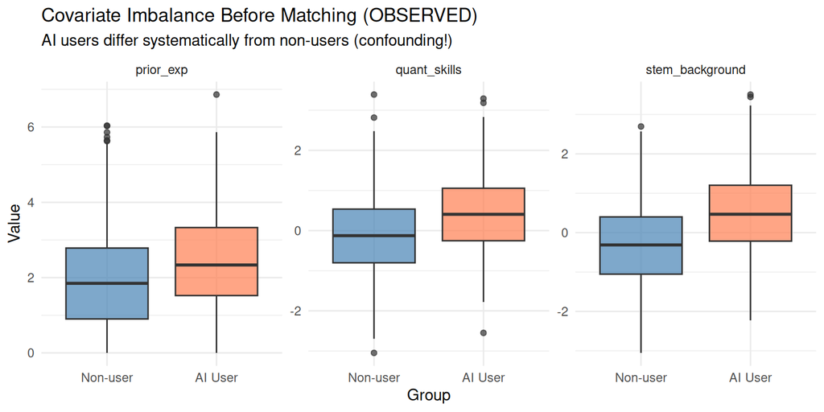

```r
plotData <- data.frame(
  value = c(prior_exp, quant_skills, stem_background),
  variable = rep(c("prior_exp", "quant_skills", "stem_background"), each = n),
  group = factor(rep(ai_user, 3), labels = c("Non-user", "AI User"))
)

ggplot(plotData, aes(x = group, y = value, fill = group)) +
  geom_boxplot(alpha = 0.7) +
  facet_wrap(~ variable, scales = "free_y") +
  scale_fill_manual(values = c("Non-user" = "steelblue", "AI User" = "coral")) +
  labs(title = "Covariate Imbalance Before Matching (OBSERVED)",
       subtitle = "AI users differ systematically from non-users (confounding!)",
       x = "Group", y = "Value") +
  theme_minimal() +
  theme(legend.position = "none")
```

## 1.8 Imbalance in UNOBSERVED Confounders

Since this is simulated data, we can peek at what we “couldn’t see” in real life:

```r
smd_cur <- calcSMD(curiosity, ai_user)
smd_tech <- calcSMD(tech_readiness, ai_user)
smd_aver <- calcSMD(ai_aversion, ai_user)
```

```r
# Perform t-tests for unobserved confounders
ttest_cur <- t.test(curiosity[ai_user == 1], curiosity[ai_user == 0])
ttest_tech <- t.test(tech_readiness[ai_user == 1], tech_readiness[ai_user == 0])
ttest_aver <- t.test(ai_aversion[ai_user == 1], ai_aversion[ai_user == 0])

balance_unobserved <- data.frame(
  Variable = c("curiosity", "tech_readiness", "ai_aversion"),
  Mean_AI_User = round(c(mean(curiosity[ai_user == 1]),
                         mean(tech_readiness[ai_user == 1]),
                         mean(ai_aversion[ai_user == 1])), 2),
  Mean_Non_User = round(c(mean(curiosity[ai_user == 0]),
                          mean(tech_readiness[ai_user == 0]),
                          mean(ai_aversion[ai_user == 0])), 2),
  SMD = round(c(smd_cur, smd_tech, smd_aver), 3),
  t_test_p = format(c(ttest_cur$p.value, ttest_tech$p.value, ttest_aver$p.value),
                    scientific = TRUE, digits = 2),
  Balance = ifelse(abs(c(smd_cur, smd_tech, smd_aver)) < 0.1, "Good",
                   ifelse(abs(c(smd_cur, smd_tech, smd_aver)) < 0.25, "OK", "Poor"))
)
kable(balance_unobserved, col.names = c("Variable", "Mean (AI User)", "Mean (Non-User)", "SMD", "t-test p", "Balance?"))
```

| Variable | Mean (AI User) | Mean (Non-User) | SMD | t-test p | Balance? |
| --- | --- | --- | --- | --- | --- |
| curiosity | 0.20 | -0.16 | 0.367 | 3.6e-08 | Poor |
| tech_readiness | 0.47 | -0.20 | 0.711 | 1.8e-24 | Poor |
| ai_aversion | -0.38 | 0.15 | -0.545 | 1.5e-15 | Poor |

**Note:** ai_aversion has NEGATIVE SMD because AI-averse students AVOID using AI!

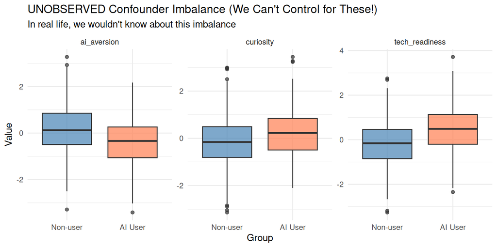

```r
plotDataUnobs <- data.frame(
  value = c(curiosity, tech_readiness, ai_aversion),
  variable = rep(c("curiosity", "tech_readiness", "ai_aversion"), each = n),
  group = factor(rep(ai_user, 3), labels = c("Non-user", "AI User"))
)

ggplot(plotDataUnobs, aes(x = group, y = value, fill = group)) +
  geom_boxplot(alpha = 0.7) +
  facet_wrap(~ variable, scales = "free_y") +
  scale_fill_manual(values = c("Non-user" = "steelblue", "AI User" = "coral")) +
  labs(title = "UNOBSERVED Confounder Imbalance (We Can't Control for These!)",
       subtitle = "In real life, we wouldn't know about this imbalance",
       x = "Group", y = "Value") +
  theme_minimal() +
  theme(legend.position = "none")
```

> **KEY INSIGHT:** Even if we match perfectly on observed confounders, these unobserved differences will still cause bias!

## 1.9 Distribution Overlap Plots

Density plots show HOW MUCH the distributions overlap. Less overlap = more imbalance = more confounding potential.

### Observed Confounders

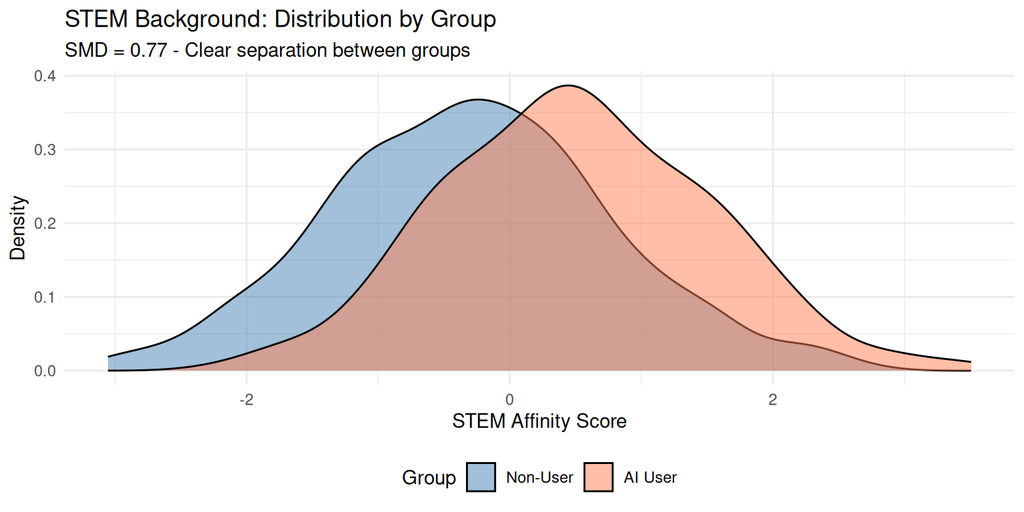

```r
ggplot(df, aes(x = stem_background, fill = factor(ai_user, labels = c("Non-User", "AI User")))) +
  geom_density(alpha = 0.5) +
  scale_fill_manual(values = c("Non-User" = "steelblue", "AI User" = "coral")) +
  labs(title = "STEM Background: Distribution by Group",
       subtitle = paste0("SMD = ", round(smd3, 2), " - Clear separation between groups"),
       x = "STEM Affinity Score", y = "Density", fill = "Group") +
  theme_minimal() +
  theme(legend.position = "bottom")
```

# Part 2: Logistic Regression Tutorial

## 2.1 Why Linear Regression Fails for Binary Outcomes

If we use linear regression to predict AI adoption (a 0/1 outcome), predictions can go below 0 or above 1. This doesn’t make sense for probabilities!

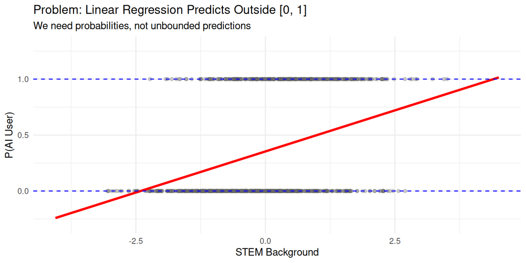

```r
linearModel <- lm(ai_user ~ stem_background, data = df)

predData <- data.frame(stem_background = seq(min(stem_background) - 1, max(stem_background) + 1, length.out = 200))
predData$linearPred <- predict(linearModel, newdata = predData)

ggplot() +
  geom_point(data = df, aes(x = stem_background, y = ai_user),
             alpha = 0.3, color = "gray40") +
  geom_line(data = predData, aes(x = stem_background, y = linearPred),
            color = "red", linewidth = 1.2) +
  geom_hline(yintercept = c(0, 1), linetype = "dashed", color = "blue") +
  labs(title = "Problem: Linear Regression Predicts Outside [0, 1]",
       subtitle = "We need probabilities, not unbounded predictions",
       x = "STEM Background", y = "P(AI User)") +
  theme_minimal() +
  ylim(-0.3, 1.3)
```

Linear regression can predict values < 0 or > 1. This doesn’t make sense for probabilities!

## 2.2 The Sigmoid Function

The sigmoid function maps any number to the range (0, 1):

$$\text{sigmoid}(z) = \frac{1}{1 +
e^{-z}}$$

```r
sigmoid <- function(z) {
  1 / (1 + exp(-z))
}
```

**Key properties:**

- Output always between 0 and 1
- sigmoid(0) = 0.5
- As z → +∞, sigmoid(z) → 1
- As z → -∞, sigmoid(z) → 0

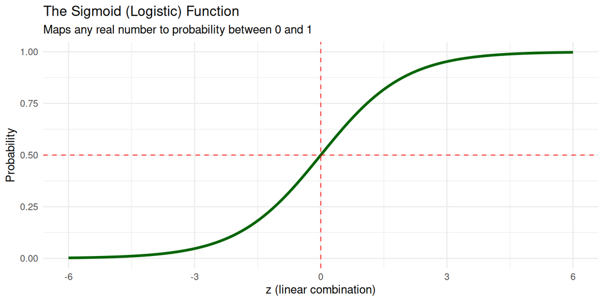

```r
zValues <- seq(-6, 6, length.out = 200)
sigmoidData <- data.frame(z = zValues, probability = sigmoid(zValues))

ggplot(sigmoidData, aes(x = z, y = probability)) +
  geom_line(color = "darkgreen", linewidth = 1.2) +
  geom_hline(yintercept = 0.5, linetype = "dashed", color = "red", alpha = 0.7) +
  geom_vline(xintercept = 0, linetype = "dashed", color = "red", alpha = 0.7) +
  labs(title = "The Sigmoid (Logistic) Function",
       subtitle = "Maps any real number to probability between 0 and 1",
       x = "z (linear combination)", y = "Probability") +
  theme_minimal()
```

## 2.3 How the Intercept Affects the Curve

The intercept shifts the curve LEFT or RIGHT:

- Larger β₀ → curve shifts LEFT (higher probabilities for same x)
- Smaller β₀ → curve shifts RIGHT (lower probabilities for same x)

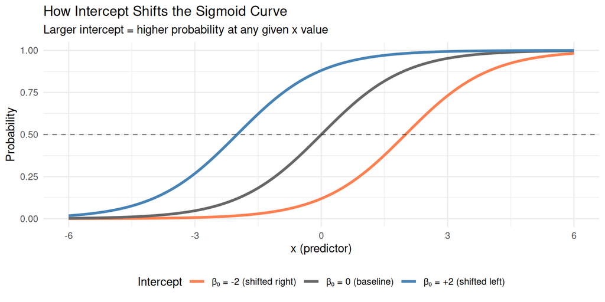

```r
interceptData <- data.frame(
  z = rep(zValues, 3),
  probability = c(sigmoid(zValues - 2), sigmoid(zValues), sigmoid(zValues + 2)),
  intercept = factor(rep(c("β₀ = -2 (shifted right)", "β₀ = 0 (baseline)", "β₀ = +2 (shifted left)"), each = 200),
                     levels = c("β₀ = -2 (shifted right)", "β₀ = 0 (baseline)", "β₀ = +2 (shifted left)"))
)

ggplot(interceptData, aes(x = z, y = probability, color = intercept)) +
  geom_line(linewidth = 1.2) +
  geom_hline(yintercept = 0.5, linetype = "dashed", alpha = 0.5) +
  scale_color_manual(values = c("coral", "gray40", "steelblue")) +
  labs(title = "How Intercept Shifts the Sigmoid Curve",
       subtitle = "Larger intercept = higher probability at any given x value",
       x = "x (predictor)", y = "Probability",
       color = "Intercept") +
  theme_minimal() +
  theme(legend.position = "bottom")
```

## 2.4 How the Slope Affects the Curve

The slope changes how STEEP the curve is:

- Larger |β₁| → steeper curve (sharper transition)
- Smaller |β₁| → flatter curve (more gradual transition)

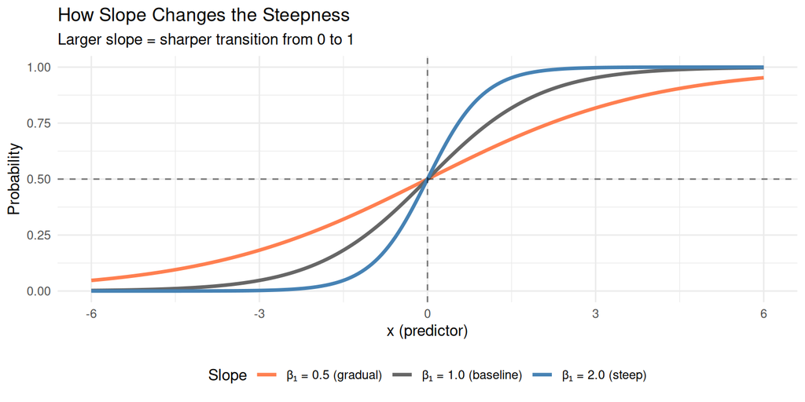

```r
slopeData <- data.frame(
  z = rep(zValues, 3),
  probability = c(sigmoid(0.5 * zValues), sigmoid(zValues), sigmoid(2 * zValues)),
  slope = factor(rep(c("β₁ = 0.5 (gradual)", "β₁ = 1.0 (baseline)", "β₁ = 2.0 (steep)"), each = 200),
                 levels = c("β₁ = 0.5 (gradual)", "β₁ = 1.0 (baseline)", "β₁ = 2.0 (steep)"))
)

ggplot(slopeData, aes(x = z, y = probability, color = slope)) +
  geom_line(linewidth = 1.2) +
  geom_hline(yintercept = 0.5, linetype = "dashed", alpha = 0.5) +
  geom_vline(xintercept = 0, linetype = "dashed", alpha = 0.5) +
  scale_color_manual(values = c("coral", "gray40", "steelblue")) +
  labs(title = "How Slope Changes the Steepness",
       subtitle = "Larger slope = sharper transition from 0 to 1",
       x = "x (predictor)", y = "Probability",
       color = "Slope") +
  theme_minimal() +
  theme(legend.position = "bottom")
```

## 2.5 Logistic vs Linear Regression Comparison

Logistic regression finds the best sigmoid curve to predict binary outcomes:

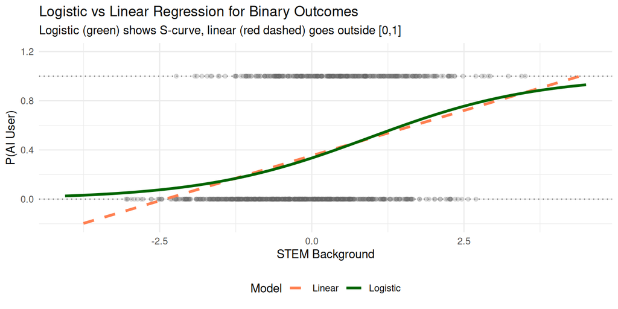

```r
logitModel <- glm(ai_user ~ stem_background, data = df, family = binomial)

predDataLogit <- data.frame(stem_background = seq(min(stem_background) - 1, max(stem_background) + 1, length.out = 200))
predDataLogit$logitPred <- predict(logitModel, newdata = predDataLogit, type = "response")
predDataLogit$linearPred <- predict(linearModel, newdata = predDataLogit)

ggplot() +
  geom_point(data = df, aes(x = stem_background, y = ai_user),
             alpha = 0.2, color = "gray40") +
  geom_line(data = predDataLogit, aes(x = stem_background, y = linearPred, color = "Linear"),
            linewidth = 1.2, linetype = "dashed") +
  geom_line(data = predDataLogit, aes(x = stem_background, y = logitPred, color = "Logistic"),
            linewidth = 1.2) +
  geom_hline(yintercept = c(0, 1), linetype = "dotted", color = "gray50") +
  scale_color_manual(values = c("Linear" = "coral", "Logistic" = "darkgreen"),
                     name = "Model") +
  labs(title = "Logistic vs Linear Regression for Binary Outcomes",
       subtitle = "Logistic (green) shows S-curve, linear (red dashed) goes outside [0,1]",
       x = "STEM Background", y = "P(AI User)") +
  theme_minimal() +
  theme(legend.position = "bottom") +
  ylim(-0.2, 1.2)
```

The logistic curve (green) fits the binary data properly! It gives us valid probabilities between 0 and 1.

# Part 3: Manual Propensity Score Calculation

## 3.1 Fit Logistic Regression Model

We model P(AI user) using **OBSERVED confounders only**:

$$P(\textrm{AI user} = 1) =
\textrm{sigmoid}(\beta_0 + \beta_1 \cdot X_1 + \beta_2 \cdot X_2 +
\beta_3 \cdot X_3)$$

Where $X_1$ = prior experience, $X_2$ = quant skills, $X_3$ = STEM background.

We CANNOT include curiosity, tech_readiness, or ai_aversion because in real life, we wouldn’t be able to measure them!

```r
psModel <- glm(ai_user ~ prior_exp + quant_skills + stem_background,
               data = df, family = binomial)

summary(psModel)
```

```
##
## Call:
## glm(formula = ai_user ~ prior_exp + quant_skills + stem_background,
##     family = binomial, data = df)
##
## Coefficients:
##                 Estimate Std. Error z value Pr(>|z|)
## (Intercept)     -1.43885    0.14502  -9.921  < 2e-16 ***
## prior_exp        0.31689    0.05498   5.764 8.22e-09 ***
## quant_skills     0.54201    0.07844   6.910 4.84e-12 ***
## stem_background  0.80019    0.07589  10.543  < 2e-16 ***
## ---
## Signif. codes:  0 '***' 0.001 '**' 0.01 '*' 0.05 '.' 0.1 ' ' 1
##
## (Dispersion parameter for binomial family taken to be 1)
##
##     Null deviance: 1294.9  on 999  degrees of freedom
## Residual deviance: 1076.2  on 996  degrees of freedom
## AIC: 1084.2
##
## Number of Fisher Scoring iterations: 4
```

## 3.2 Extract Coefficients

```r
beta0 <- coef(psModel)["(Intercept)"]
beta1 <- coef(psModel)["prior_exp"]
beta2 <- coef(psModel)["quant_skills"]
beta3 <- coef(psModel)["stem_background"]
```

```r
coef_table <- data.frame(
  Coefficient = c("B0 (Intercept)", "B1 (prior_exp)", "B2 (quant_skills)", "B3 (stem_background)"),
  Value = round(c(beta0, beta1, beta2, beta3), 4)
)
kable(coef_table)
```

|  | Coefficient | Value |
| --- | --- | --- |
| (Intercept) | B0 (Intercept) | -1.4388 |
| prior_exp | B1 (prior_exp) | 0.3169 |
| quant_skills | B2 (quant_skills) | 0.5420 |
| stem_background | B3 (stem_background) | 0.8002 |

## 3.3 Manual Propensity Score Calculation

Now let’s calculate propensity scores manually using a for loop:

```r
pscore <- numeric(n)

for (i in 1:n) {
  z <- beta0 + beta1 * df$prior_exp[i] + beta2 * df$quant_skills[i] + beta3 * df$stem_background[i]
  pscore[i] <- sigmoid(z)

  # Print first 3 for demonstration
  if (i <= 3) {
    cat("Student", i, ":\n")
    cat("  prior_exp =", round(df$prior_exp[i], 2),
        ", quant_skills =", round(df$quant_skills[i], 2),
        ", stem_background =", round(df$stem_background[i], 2), "\n")
    cat("  z =", round(z, 3), "\n")
    cat("  P(AI user) = sigmoid(", round(z, 3), ") =", round(pscore[i], 4), "\n\n")
  }
}
```

```
## Student 1 :
##   prior_exp = 1.16 , quant_skills = -1 , stem_background = -0.59
##   z = -2.081
##   P(AI user) = sigmoid( -2.081 ) = 0.111
##
## Student 2 :
##   prior_exp = 1.65 , quant_skills = -1.04 , stem_background = 0.07
##   z = -1.42
##   P(AI user) = sigmoid( -1.42 ) = 0.1947
##
## Student 3 :
##   prior_exp = 4.34 , quant_skills = -0.02 , stem_background = -1.27
##   z = -1.087
##   P(AI user) = sigmoid( -1.087 ) = 0.2522
```

```r
df$pscore <- pscore
```

## 3.4 Verify Our Calculation

Let’s make sure our manual calculation matches R’s built-in prediction:

```r
builtinPscore <- predict(psModel, type = "response")
maxDiff <- max(abs(pscore - builtinPscore))
```

Maximum difference between manual and built-in: 2.220446e-16

✓ Our manual calculation matches!

## 3.5 Propensity Score Distributions

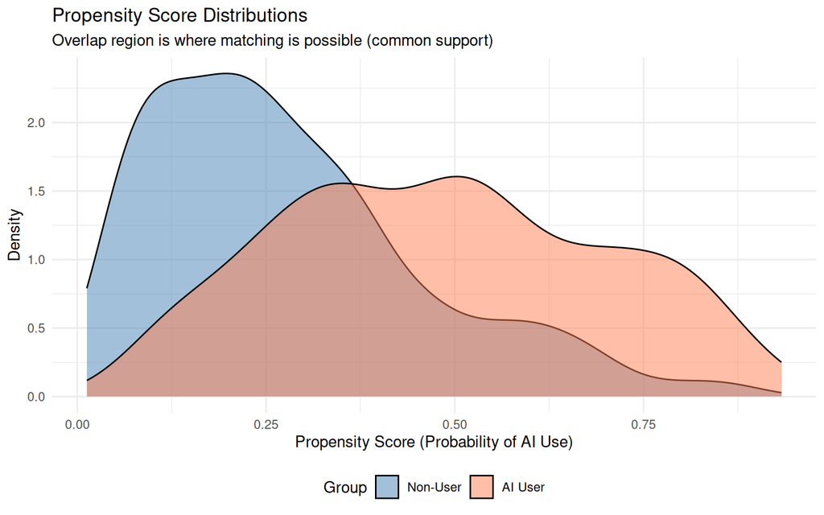

```r
df$group <- factor(df$ai_user, labels = c("Non-User", "AI User"))

ggplot(df, aes(x = pscore, fill = group)) +
  geom_density(alpha = 0.5) +
  scale_fill_manual(values = c("Non-User" = "steelblue", "AI User" = "coral")) +
  labs(title = "Propensity Score Distributions",
       subtitle = "Overlap region is where matching is possible (common support)",
       x = "Propensity Score (Probability of AI Use)", y = "Density",
       fill = "Group") +
  theme_minimal() +
  theme(legend.position = "bottom")
```

- **Non-users:** scores concentrated at lower values (mean ≈ 0.28)
- **AI users:** scores concentrated at higher values (mean ≈ 0.48)

The **overlap** between distributions is the **common support** - the region where matching is possible.

# Part 4: Manual Nearest-Neighbor Matching

## 4.1 Setup for Matching

```r
df$matched <- 0
df$matchGroup <- NA

treatedIdx <- which(df$ai_user == 1)
controlIdx <- which(df$ai_user == 0)

nTreated <- length(treatedIdx)
nControl <- length(controlIdx)

# Caliper = 0.2 * SD of propensity scores
caliper <- 0.2 * sd(df$pscore)
```

- **Treated units:** 350
- **Control units:** 650
- **Caliper:** 0.0433 (0.2 × SD of propensity scores)

## 4.2 The Matching Algorithm

For each treated unit, find the nearest unmatched control within the caliper:

```r
pairID <- 0
droppedDueToCaliper <- 0

for (i in 1:nTreated) {
  tIdx <- treatedIdx[i]
  tPscore <- df$pscore[tIdx]

  # Find unmatched controls
  availableControls <- which(df$ai_user == 0 & df$matched == 0)

  if (length(availableControls) == 0) {
    droppedDueToCaliper <- droppedDueToCaliper + 1
    next
  }

  # Find nearest neighbor
  bestControlIdx <- NA
  bestDistance <- Inf

  for (cIdx in availableControls) {
    distance <- abs(tPscore - df$pscore[cIdx])
    if (distance < bestDistance) {
      bestDistance <- distance
      bestControlIdx <- cIdx
    }
  }

  # Check caliper
  if (bestDistance > caliper) {
    droppedDueToCaliper <- droppedDueToCaliper + 1
    next
  }

  # Create match
  pairID <- pairID + 1
  df$matched[tIdx] <- 1
  df$matched[bestControlIdx] <- 1
  df$matchGroup[tIdx] <- pairID
  df$matchGroup[bestControlIdx] <- pairID
}
```

## 4.3 Matching Results

```r
dfMatched <- df[df$matched == 1, ]

nMatchedTreated <- sum(dfMatched$ai_user == 1)
nMatchedControl <- sum(dfMatched$ai_user == 0)
nDroppedTreated <- sum(df$ai_user == 1) - nMatchedTreated
```

```r
matching_summary <- data.frame(
  Group = c("Total", "AI Users", "Non-Users"),
  Before = c(n, sum(df$ai_user == 1), sum(df$ai_user == 0)),
  After = c(nrow(dfMatched), nMatchedTreated, nMatchedControl)
)
kable(matching_summary)
```

| Group | Before | After |
| --- | --- | --- |
| Total | 1000 | 536 |
| AI Users | 350 | 268 |
| Non-Users | 650 | 268 |

**Dropped due to caliper:** 82 AI users (23%)

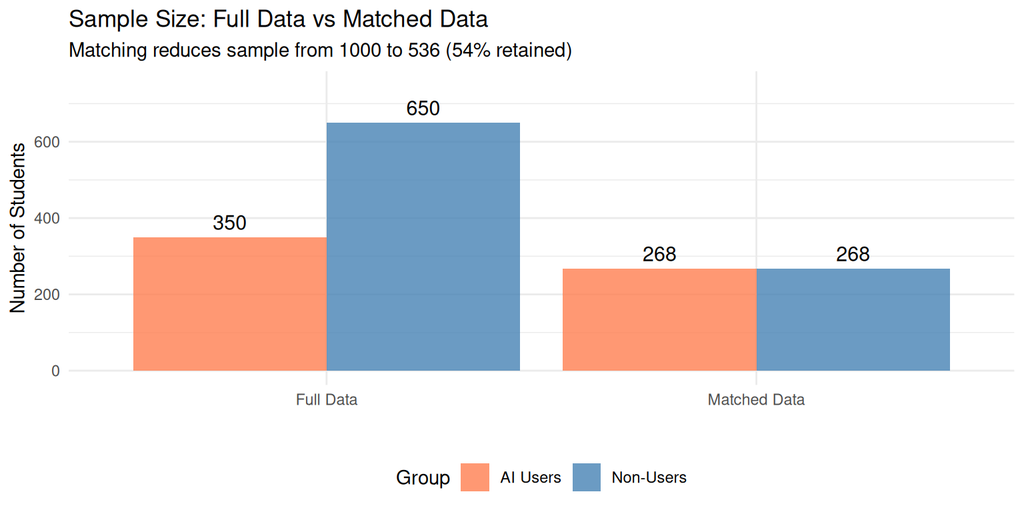

```r
sampleSizeData <- data.frame(
  dataset = factor(rep(c("Full Data", "Matched Data"), each = 2),
                   levels = c("Full Data", "Matched Data")),
  group = rep(c("AI Users", "Non-Users"), 2),
  count = c(sum(df$ai_user == 1), sum(df$ai_user == 0),
            nMatchedTreated, nMatchedControl)
)

ggplot(sampleSizeData, aes(x = dataset, y = count, fill = group)) +
  geom_bar(stat = "identity", position = "dodge", alpha = 0.8) +
  geom_text(aes(label = count), position = position_dodge(width = 0.9),
            vjust = -0.5, size = 4) +
  scale_fill_manual(values = c("AI Users" = "coral", "Non-Users" = "steelblue")) +
  labs(title = "Sample Size: Full Data vs Matched Data",
       subtitle = paste0("Matching reduces sample from ", n, " to ", nrow(dfMatched),
                        " (", round(100 * nrow(dfMatched)/n), "% retained)"),
       x = "", y = "Number of Students", fill = "Group") +
  theme_minimal() +
  theme(legend.position = "bottom") +
  ylim(0, max(sampleSizeData$count) * 1.15)
```

> **TRADE-OFF:** Matching improves balance but REDUCES sample size. The caliper drops treated units with no good matches.

# Part 5: Balance Assessment

## 5.1 SMD Before vs After

```r
# Before
smd1_before <- calcSMD(df$prior_exp, df$ai_user)
smd2_before <- calcSMD(df$quant_skills, df$ai_user)
smd3_before <- calcSMD(df$stem_background, df$ai_user)

# After
smd1_after <- calcSMD(dfMatched$prior_exp, dfMatched$ai_user)
smd2_after <- calcSMD(dfMatched$quant_skills, dfMatched$ai_user)
smd3_after <- calcSMD(dfMatched$stem_background, dfMatched$ai_user)
```

### OBSERVED Confounders

```r
# T-tests BEFORE matching
ttest1_before <- t.test(df$prior_exp[df$ai_user == 1], df$prior_exp[df$ai_user == 0])
ttest2_before <- t.test(df$quant_skills[df$ai_user == 1], df$quant_skills[df$ai_user == 0])
ttest3_before <- t.test(df$stem_background[df$ai_user == 1], df$stem_background[df$ai_user == 0])

# T-tests AFTER matching
ttest1_after <- t.test(dfMatched$prior_exp[dfMatched$ai_user == 1], dfMatched$prior_exp[dfMatched$ai_user == 0])
ttest2_after <- t.test(dfMatched$quant_skills[dfMatched$ai_user == 1], dfMatched$quant_skills[dfMatched$ai_user == 0])
ttest3_after <- t.test(dfMatched$stem_background[dfMatched$ai_user == 1], dfMatched$stem_background[dfMatched$ai_user == 0])

smd_comparison_observed <- data.frame(
  Variable = c("prior_exp", "quant_skills", "stem_background"),
  SMD_Before = round(c(smd1_before, smd2_before, smd3_before), 3),
  p_Before = format(c(ttest1_before$p.value, ttest2_before$p.value, ttest3_before$p.value),
                    scientific = TRUE, digits = 2),
  SMD_After = round(c(smd1_after, smd2_after, smd3_after), 3),
  p_After = format(c(ttest1_after$p.value, ttest2_after$p.value, ttest3_after$p.value),
                   scientific = TRUE, digits = 2),
  Balanced = ifelse(abs(c(smd1_after, smd2_after, smd3_after)) < 0.1, "Yes", "No")
)
kable(smd_comparison_observed, col.names = c("Variable", "SMD Before", "p Before", "SMD After", "p After", "Balanced?"))
```

| Variable | SMD Before | p Before | SMD After | p After | Balanced? |
| --- | --- | --- | --- | --- | --- |
| prior_exp | 0.380 | 1.6e-08 | -0.019 | 8.3e-01 | Yes |
| quant_skills | 0.498 | 1.8e-13 | 0.010 | 9.1e-01 | Yes |
| stem_background | 0.774 | 2.2e-29 | 0.008 | 9.3e-01 | Yes |

**Note:** p < 0.05 means groups are significantly different. After matching, we want p > 0.05!

## 5.2 What About UNOBSERVED Confounders?

Since we simulated this data, we can peek behind the curtain…

```r
smd_cur_before <- calcSMD(df$curiosity, df$ai_user)
smd_tech_before <- calcSMD(df$tech_readiness, df$ai_user)
smd_aver_before <- calcSMD(df$ai_aversion, df$ai_user)

smd_cur_after <- calcSMD(dfMatched$curiosity, dfMatched$ai_user)
smd_tech_after <- calcSMD(dfMatched$tech_readiness, dfMatched$ai_user)
smd_aver_after <- calcSMD(dfMatched$ai_aversion, dfMatched$ai_user)
```

### UNOBSERVED Confounders (we can’t control for these!)

```r
# T-tests BEFORE matching (unobserved)
ttest_cur_before <- t.test(df$curiosity[df$ai_user == 1], df$curiosity[df$ai_user == 0])
ttest_tech_before <- t.test(df$tech_readiness[df$ai_user == 1], df$tech_readiness[df$ai_user == 0])
ttest_aver_before <- t.test(df$ai_aversion[df$ai_user == 1], df$ai_aversion[df$ai_user == 0])

# T-tests AFTER matching (unobserved)
ttest_cur_after <- t.test(dfMatched$curiosity[dfMatched$ai_user == 1], dfMatched$curiosity[dfMatched$ai_user == 0])
ttest_tech_after <- t.test(dfMatched$tech_readiness[dfMatched$ai_user == 1], dfMatched$tech_readiness[dfMatched$ai_user == 0])
ttest_aver_after <- t.test(dfMatched$ai_aversion[dfMatched$ai_user == 1], dfMatched$ai_aversion[dfMatched$ai_user == 0])

smd_comparison_unobserved <- data.frame(
  Variable = c("curiosity", "tech_readiness", "ai_aversion"),
  SMD_Before = round(c(smd_cur_before, smd_tech_before, smd_aver_before), 3),
  p_Before = format(c(ttest_cur_before$p.value, ttest_tech_before$p.value, ttest_aver_before$p.value),
                    scientific = TRUE, digits = 2),
  SMD_After = round(c(smd_cur_after, smd_tech_after, smd_aver_after), 3),
  p_After = format(c(ttest_cur_after$p.value, ttest_tech_after$p.value, ttest_aver_after$p.value),
                   scientific = TRUE, digits = 2),
  Balanced = ifelse(abs(c(smd_cur_after, smd_tech_after, smd_aver_after)) < 0.1, "Yes", "No")
)
kable(smd_comparison_unobserved, col.names = c("Variable", "SMD Before", "p Before", "SMD After", "p After", "Balanced?"))
```

| Variable | SMD Before | p Before | SMD After | p After | Balanced? |
| --- | --- | --- | --- | --- | --- |
| curiosity | 0.367 | 3.6e-08 | 0.416 | 2.0e-06 | No |
| tech_readiness | 0.711 | 1.8e-24 | 0.999 | 9.6e-28 | No |
| ai_aversion | -0.545 | 1.5e-15 | -0.699 | 3.8e-15 | No |

> **KEY INSIGHT:** Matching on observed confounders does NOT balance unobserved ones! This is why we’ll still have bias in our estimates.

## 5.3 Love Plot

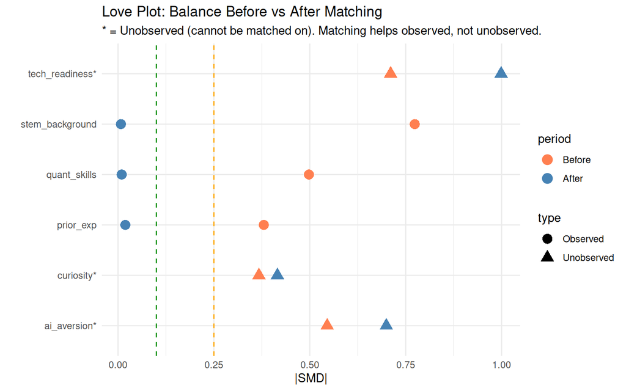

```r
lovePlotData <- data.frame(
  variable = rep(c("prior_exp", "quant_skills", "stem_background",
                   "curiosity*", "tech_readiness*", "ai_aversion*"), 2),
  SMD = c(smd1_before, smd2_before, smd3_before, smd_cur_before, smd_tech_before, smd_aver_before,
          smd1_after, smd2_after, smd3_after, smd_cur_after, smd_tech_after, smd_aver_after),
  period = factor(rep(c("Before", "After"), each = 6), levels = c("Before", "After")),
  type = rep(c(rep("Observed", 3), rep("Unobserved", 3)), 2)
)

ggplot(lovePlotData, aes(x = abs(SMD), y = variable, color = period, shape = type)) +
  geom_point(size = 4) +
  geom_vline(xintercept = 0.1, linetype = "dashed", color = "green4") +
  geom_vline(xintercept = 0.25, linetype = "dashed", color = "orange") +
  scale_color_manual(values = c("Before" = "coral", "After" = "steelblue")) +
  labs(title = "Love Plot: Balance Before vs After Matching",
       subtitle = "* = Unobserved (cannot be matched on). Matching helps observed, not unobserved.",
       x = "|SMD|", y = "") +
  theme_minimal()
```

## 5.4 Density Overlap: Before vs After

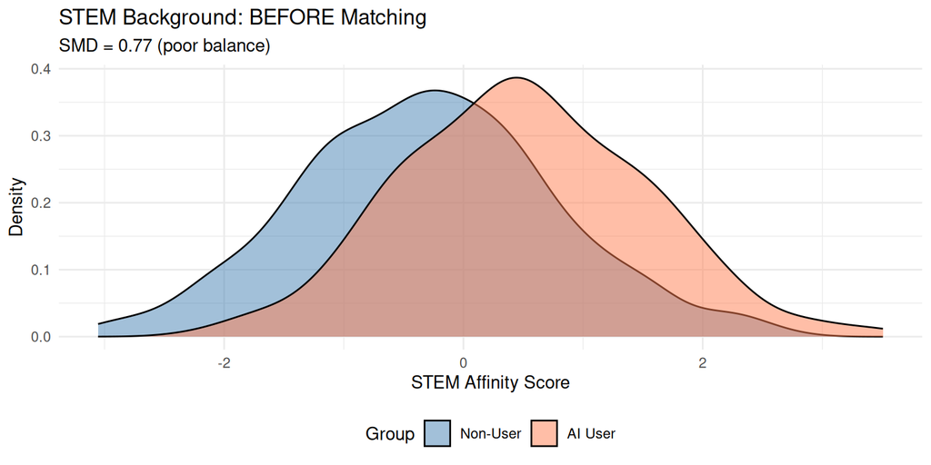

```r
# STEM background - before
ggplot(df, aes(x = stem_background, fill = factor(ai_user, labels = c("Non-User", "AI User")))) +
  geom_density(alpha = 0.5) +
  scale_fill_manual(values = c("Non-User" = "steelblue", "AI User" = "coral")) +
  labs(title = "STEM Background: BEFORE Matching",
       subtitle = paste0("SMD = ", round(smd3_before, 2), " (poor balance)"),
       x = "STEM Affinity Score", y = "Density", fill = "Group") +
  theme_minimal() +
  theme(legend.position = "bottom")
```

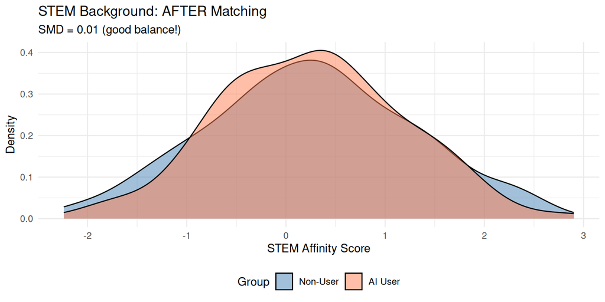

```r
# STEM background - after
ggplot(dfMatched, aes(x = stem_background, fill = factor(ai_user, labels = c("Non-User", "AI User")))) +
  geom_density(alpha = 0.5) +
  scale_fill_manual(values = c("Non-User" = "steelblue", "AI User" = "coral")) +
  labs(title = "STEM Background: AFTER Matching",
       subtitle = paste0("SMD = ", round(smd3_after, 2), " (good balance!)"),
       x = "STEM Affinity Score", y = "Density", fill = "Group") +
  theme_minimal() +
  theme(legend.position = "bottom")
```